# Homework_4

Ramazan Yarar

12/9/2018

## Homework_4

# Dataset1

The dataset is about bankruptcy prediction of Polish companies.The data contains financial rates from 5th year of the forecasting period and corresponding class label that indicates bankruptcy status after 1 year. The data contains 5910 instances (financial statements), 410 represents bankrupted companies, 5500 firms that did not bankrupt in the forecasting period. It is example for imbalanced data

```r
#library
library(dplyr)
library(earth)
library(methods)
library(data.table)
library(zoo)
library(missForest)
library(Metrics)
library(foreign)
library(glmnet)
library(tidyverse)
library(caret)
```

```r
# read data
databank=read.arff("~/Documents/Dersler/Fall-2018/IE-582/Homework4/5year.arff")
dt_bank<-data.table(databank)
# replace missing value with zero
dt_bank[is.na(dt_bank)] <- 0

#split data
training.bank <- dt_bank$class %>% createDataPartition(p = 0.8, list = FALSE)
trainbank<-dt_bank[training.bank,]
testbank<-dt_bank[-training.bank]

x_trainbank<- as.matrix(trainbank[,1:64])
y_trainbank<- trainbank$class

x_testbank<- as.matrix(testbank[,1:64])
y_testbank<- testbank$class

summarybank=data.table(algorithms=character(), AccuracyTrain=numeric(),AccuracyTest=numeric())
```

- Dataset1 PRA

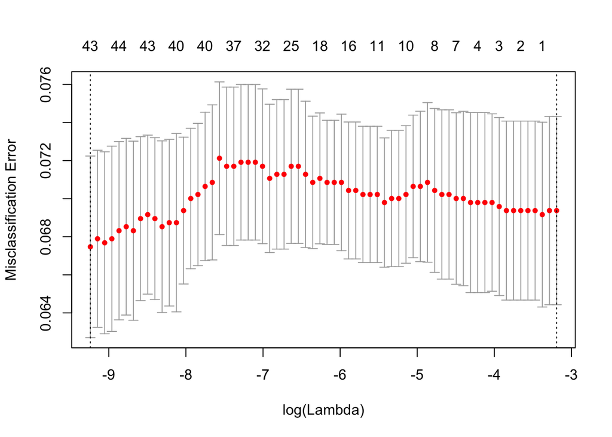

```r
modelprabank <- cv.glmnet(x_trainbank, y_trainbank, alpha = 1,nfolds=5,type.measure='class',family="binomial")

prabanktrainaccuracy<-1-min(as.numeric(modelprabank$cvm))


y_prabankpredicted<-predict(modelprabank,x_testbank,type = "class",s=modelprabank$lambda.min)

banktable_confusionpra<-table(y_testbank,y_prabankpredicted)

pranewstestaccuracy <- sum(diag(banktable_confusionpra)) / sum(banktable_confusionpra)

#mean(y_predicted == y_test)

summarybank<-rbind(summarybank,list("pra",prabanktrainaccuracy,pranewstestaccuracy))


plot(modelprabank)
```

- Dataset1 Decision Tree

```r
dtresultsbank=data.table(minbucket=numeric(), Accuracy=numeric(), cp=numeric())

#find best parameter
for (minbucket in c(5,8,10,15))
{

dtbankGrid<-expand.grid(cp = c(0.05,0.01, 0.1, 0.15,0.20))
control <- trainControl(method="cv", number=6, search="grid")
innerdtreebank <- train(class ~ ., data=trainbank, method="rpart", metric="Accuracy",minbucket =minbucket, tuneLength=5, trControl=control,tuneGrid = dtbankGrid)

resulttempbank<-innerdtreebank$results[,c("Accuracy","cp")]
resulttempbank$minbucket<-minbucket
dtresultsbank<-rbind(resulttempbank,dtresultsbank)
}

bestprdtbank<-dtresultsbank[,bestrnk:=rank(-Accuracy,ties.method= "min")][bestrnk==1]
bestminbucketbank<-bestprdtbank[,c("minbucket")]
bestcpbank<-bestprdtbank[,c("cp")]

#print(dtresultsbank)

#fit model best parameter
dtbankGrid <-  expand.grid(cp =bestcpbank)
control <- trainControl(method="cv", number=5, search="grid")
dtreebank <- train(class ~ ., data=trainbank, method="rpart", metric="Accuracy",minbucket =bestminbucketbank, trControl=control,tuneGrid = dtbankGrid)

#predict test data
y_dtbankpredicted<-predict(dtreebank,x_testbank)
banktable_confusiondt<-table(y_testbank,y_dtbankpredicted)

dtreebanktestaccuracy <- sum(diag(banktable_confusiondt)) / sum(banktable_confusiondt)
dtreebanktrainaccuracy<-as.numeric(bestprdtbank[,c("Accuracy")])

summarybank<-rbind(summarybank,list("decisiontree",dtreebanktrainaccuracy,dtreebanktestaccuracy))

print(as.matrix(dtresultsbank))
```

```
##        Accuracy   cp minbucket bestrnk
##  [1,] 0.9555837 0.01        15       1
##  [2,] 0.9473331 0.05        15       8
##  [3,] 0.9466994 0.10        15      15
##  [4,] 0.9466994 0.15        15      15
##  [5,] 0.9466994 0.20        15      15
##  [6,] 0.9541029 0.01        10       3
##  [7,] 0.9494482 0.05        10       6
##  [8,] 0.9466986 0.10        10      18
##  [9,] 0.9466986 0.15        10      18
## [10,] 0.9466986 0.20        10      18
## [11,] 0.9505068 0.01         8       4
## [12,] 0.9483939 0.05         8       7
## [13,] 0.9467013 0.10         8      12
## [14,] 0.9467013 0.15         8      12
## [15,] 0.9467013 0.20         8      12
## [16,] 0.9545278 0.01         5       2
## [17,] 0.9500854 0.05         5       5
## [18,] 0.9469109 0.10         5       9
## [19,] 0.9469109 0.15         5       9
## [20,] 0.9469109 0.20         5       9
```

- Dataset1 Random Forest

```r
# Grid search
control <- trainControl(method="cv", number=6, search="grid")

# nodesize(the minimal number of observations per tree leaf) is 5, number of tree 500,
# 5  mtry value for tuning

rfbankgrid<-expand.grid(mtry = c(5,10, 20,30,35))
rfbank <- train(class ~ ., data=trainbank, method="rf", metric="Accuracy",ntree =500,nodesize=5, trControl=control,tuneGrid = rfbankgrid)

y_rfbankpredicted<-predict(rfbank,x_testbank)
table_confusionbankrf<-table(y_testbank,y_rfbankpredicted)
rfbanktestaccuracy <- sum(diag(table_confusionbankrf)) / sum(table_confusionbankrf)
rfbanktrainaccuracy<-as.numeric(max(rfbank$results$Accuracy))

summarybank<-rbind(summarybank,list("randomforest",rfbanktrainaccuracy,rfbanktestaccuracy))

print(rfbank)
```

```
## Random Forest
##
## 4728 samples
##   64 predictor
##    2 classes: '0', '1'
##
## No pre-processing
## Resampling: Cross-Validated (6 fold)
## Summary of sample sizes: 3939, 3940, 3941, 3939, 3941, 3940, ...
## Resampling results across tuning parameters:
##
##   mtry  Accuracy   Kappa
##    5    0.9477612  0.4413967
##   10    0.9528371  0.5169606
##   20    0.9560083  0.5589408
##   30    0.9574902  0.5758065
##   35    0.9581231  0.5830747
##
## Accuracy was used to select the optimal model using the largest value.
## The final value used for the model was mtry = 35.
```

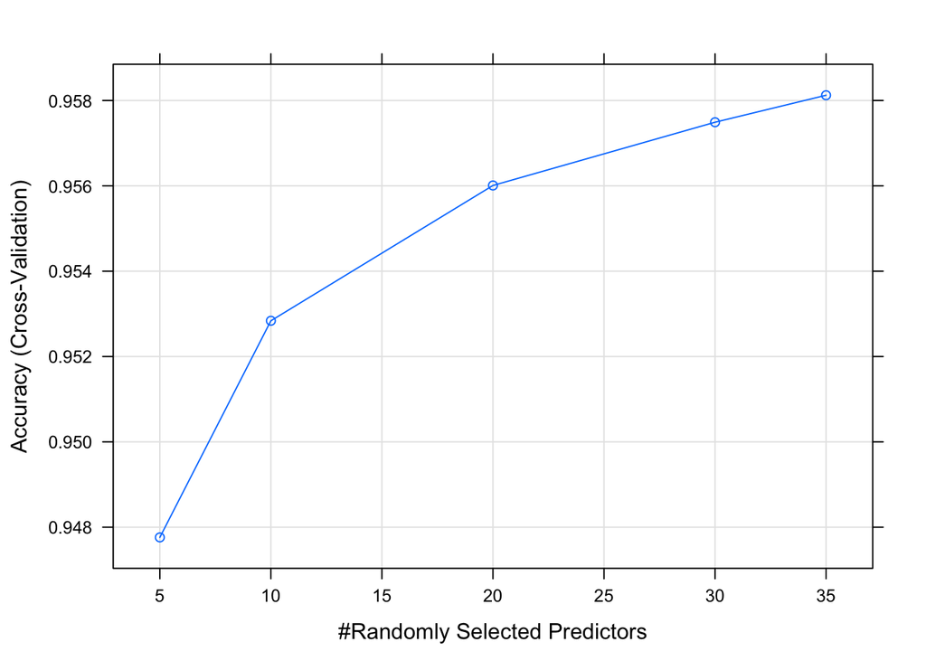

```r
plot(rfbank)
```

- Dataset1 Gradient Boosting Trees

```r
control <- trainControl(method="cv", number=3, search="grid")

gbmGridbank <-  expand.grid(interaction.depth = c(2, 5, 10),
                        n.trees = c(500, 1000, 1500),
                        shrinkage = c(0.05,0.1, 0.2),
                        n.minobsinnode = 10)

gbmtrainbank <- train(class ~ ., data=trainbank, method="gbm", metric="Accuracy", trControl=control,tuneGrid = gbmGridbank)
```

```r
y_gbmbankpredicted<-predict(gbmtrainbank,x_testbank)
table_confusiongbmbank<-table(y_testbank,y_gbmbankpredicted)
gbmbanktestaccuracy <- sum(diag(table_confusiongbmbank)) / sum(table_confusiongbmbank)
gbmbanktrainaccuracy<-max(gbmtrainbank$results$Accuracy)


#gbmtrainbank$bestTune
print(as.matrix(gbmtrainbank$results))
```

```
##    shrinkage interaction.depth n.minobsinnode n.trees  Accuracy     Kappa
## 1       0.05                 2             10     500 0.9536798 0.5530427
## 10      0.10                 2             10     500 0.9515651 0.5453079
## 19      0.20                 2             10     500 0.9513527 0.5543699
## 4       0.05                 5             10     500 0.9547365 0.5743195
## 13      0.10                 5             10     500 0.9562162 0.5899280
## 22      0.20                 5             10     500 0.9587554 0.6264232
## 7       0.05                10             10     500 0.9566406 0.5939985
## 16      0.10                10             10     500 0.9574866 0.6064794
## 25      0.20                10             10     500 0.9576981 0.6127058
## 2       0.05                 2             10    1000 0.9526229 0.5566599
## 11      0.10                 2             10    1000 0.9536794 0.5679677
## 20      0.20                 2             10    1000 0.9517756 0.5507126
## 5       0.05                 5             10    1000 0.9562172 0.5919334
## 14      0.10                 5             10    1000 0.9581209 0.6207305
```

[output cut: 41 more lines]

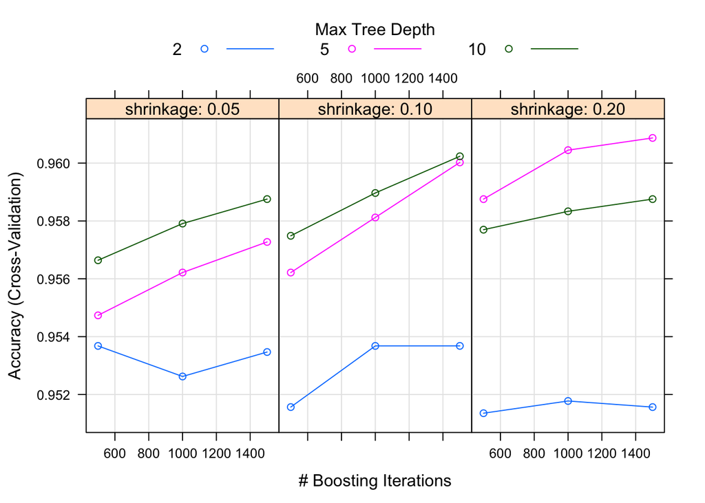

```r
plot(gbmtrainbank)
```

```r
summarybank<-rbind(summarybank,list("gbm",gbmbanktrainaccuracy,gbmbanktestaccuracy))
```

- Dataset1 SVM

```r
resultsvmbank=data.table(degree=numeric(), Accuracy=numeric(), C=numeric())
for (degree in c(1,2,3))
{

control <- trainControl(method="cv", number=2, search="random")
svmtrainbankinner <- train(class ~ ., data=trainbank, method="svmPoly", metric="Accuracy",degree=degree, tuneLength=5, trControl=control)
svmtrainbankinner$results
resulttempsvm<-svmtrainbankinner$results[,c("Accuracy","C")]
resulttempsvm$degree<-degree
resultsvmbank<-rbind(resultsvmbank,resulttempsvm)
}


bestprdtbanksvm<-resultsvmbank[,bestrnk:=rank(-Accuracy,ties.method= "min")][bestrnk==1]
bestdegreebank<-bestprdtbanksvm[,c("degree")]
bestcbank<-bestprdtbanksvm[,c("C")]

#print(dtresultsbank)

#fit model best parameter
dtbankGrid <-  expand.grid(C =bestcbank)
control <- trainControl(method="cv", number=2, search="grid")
svmbank <- train(class ~ ., data=trainbank, method="svmPoly", metric="Accuracy",degree=bestdegreebank, trControl=control)
#predict test data
y_dtbankpredictedsvm<-predict(dtreebank,x_testbank)
banktable_confusionsvm<-table(y_testbank,y_dtbankpredictedsvm)


#evaluate
svmbanktestaccuracy <- sum(diag(banktable_confusionsvm)) / sum(banktable_confusionsvm)
svmbanktrainaccuracy<-as.numeric(bestprdtbanksvm[,c("Accuracy")])

summarybank<-rbind(summarybank,list("svm",svmbanktrainaccuracy,svmbanktestaccuracy))

print(as.matrix(resultsvmbank))
```

```
##       degree  Accuracy            C bestrnk
##  [1,]      1 0.9306261   0.59784924       7
##  [2,]      1 0.9295685   0.98182649      12
##  [3,]      1 0.9304146   0.25785439      11
##  [4,]      1 0.8969966  62.82789347      15
##  [5,]      1 0.9228003   0.06316139      13
##  [6,]      2 0.9306261   2.62828083       7
##  [7,]      2 0.9310491  13.86947974       4
##  [8,]      2 0.9306261   0.43730903       7
##  [9,]      2 0.9308376   0.10926473       6
## [10,]      2 0.9101100 290.97243692      14
## [11,]      3 0.9310491   4.63881745       4
## [12,]      3 0.9363367 357.56412501       1
## [13,]      3 0.9306261   0.70286402       7
## [14,]      3 0.9329526   0.08123364       3
## [15,]      3 0.9348562  24.94034802       2
```

```r
print(as.matrix(summarybank))
```

```
##      algorithms     AccuracyTrain AccuracyTest
## [1,] "pra"          "0.9325296"   "0.9323181"
## [2,] "decisiontree" "0.9555837"   "0.9517766"
## [3,] "randomforest" "0.9581231"   "0.9534687"
## [4,] "gbm"          "0.9608707"   "0.9661591"
## [5,] "svm"          "0.9363367"   "0.9517766"
```

GBM algorithm provide best test and train accuracy. Because of cross validation , overfitting doesn’t seen

# Dataset 2

This data set consists of three types of entities: (a) the specification of an auto in terms of various characteristics, (b) its assigned insurance risk rating, (c) its normalized losses in use as compared to other cars. The second rating corresponds to the degree to which the auto is more risky than its price indicates. Cars are initially assigned a risk factor symbol associated with its price. Then, if it is more risky (or less), this symbol is adjusted by moving it up (or down) the scale. Actuarians call this process “symboling”. A value of +3 indicates that the auto is risky, -3 that it is probably pretty safe. 205 instance, 26 features

```r
summaryauto=data.table(algorithms=character(), AccuracyTrain=numeric(),AccuracyTest=numeric())


dataauto=read.table("~/Documents/Dersler/Fall-2018/IE-582/Homework4/imports-85.data.txt",header = TRUE, sep = ",")
dt_auto<-data.table(dataauto)


# replace missing value with prediction of missForest

dt_auto[dt_auto=='?']<-NA
dt_auto[,2]<-NULL
autopart1<-dt_auto[,1:20]
autopart2<-dt_auto[,21:25]
impute<-missForest(autopart1)

autopart1<-impute$ximp

dt_auto<-cbind(autopart1,autopart2)

dt_auto$horsepower<-ifelse(is.na(dt_auto$horsepower),is.numeric(mean(dt_auto$horsepower,na.rm=TRUE)),dt_auto$horsepower)
dt_auto$peak.rpm<-ifelse(is.na(dt_auto$peak.rpm),is.numeric(mean(dt_auto$peak.rpm,na.rm=TRUE)),dt_auto$peak.rpm)
dt_auto$price<-ifelse(is.na(dt_auto$price),is.numeric(mean(dt_auto$price,na.rm=TRUE)),dt_auto$price)

# Because -2 category has only two instance , group by -1
dt_auto$symboling<-ifelse(dt_auto$symboling==-2,-1,dt_auto$symboling)

#split train and test

dt_auto[bore=="3,34"]<-NULL
training.auto <- dt_auto$symboling %>% createDataPartition(p = 0.8, list = FALSE)
trainauto<-dt_auto[training.auto,]
testauto<-dt_auto[-training.auto]


x_trainauto<- as.matrix(trainauto[,2:25])
y_trainauto<- trainauto$symboling

x_testauto<- testauto[,2:25]
y_testauto<- testauto$symboling
```

- Dataset 2 PRA model

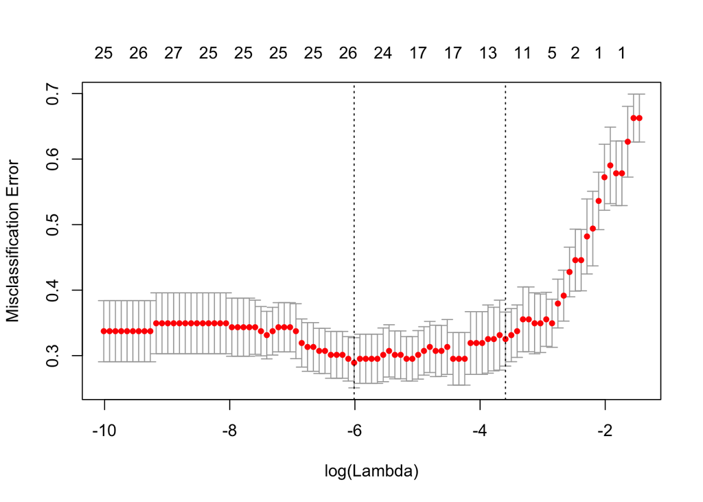

```r
# create dummies for categorical variable
#summary(dt_auto)
x_trainautoct<-trainauto[,c("symboling","make","fuel.type","aspiration","num.of.doors","body.style","drive.wheels","engine.location","engine.type","num.of.cylinders","fuel.system")]
x_trainautocon<-trainauto[,c("wheel.base","length","width","height","curb.weight","engine.size","bore","stroke","compression.ratio","horsepower","peak.rpm","city.mpg","highway.mpg","price")]

dummies<-dummyVars(symboling ~ .,data=data.table(x_trainautoct))
x_trainautoct<-data.table(predict(dummies,newdata=x_trainautoct))
x_trainrpaauto<-as.matrix(cbind(x_trainautoct,x_trainautocon))

#for test data
x_testautoct<-testauto[,c("symboling","make","fuel.type","aspiration","num.of.doors","body.style","drive.wheels","engine.location","engine.type","num.of.cylinders","fuel.system")]
x_testautocon<-testauto[,c("wheel.base","length","width","height","curb.weight","engine.size","bore","stroke","compression.ratio","horsepower","peak.rpm","city.mpg","highway.mpg","price")]


dummiestest<-dummyVars(symboling ~ .,data=data.table(x_testautoct))
x_testautoct<-data.table(predict(dummiestest,newdata=x_testautoct))
x_testrpaauto<-as.matrix(cbind(x_testautoct,x_testautocon))




# model fit


modelrpaauto <- cv.glmnet(as(x_trainrpaauto,"dgCMatrix"),as.factor(y_trainauto), alpha =1,nfolds=6,type.measure='class',family="multinomial")


rpaautotrainaccuracy<-1-min(as.numeric(modelrpaauto$cvm))


y_praautopredicted<-predict(modelrpaauto,as(x_testrpaauto,"dgCMatrix"),type = "class",s=modelrpaauto$lambda.min)

autotable_confusionrpa<-table(y_testauto,y_praautopredicted)

praautotestaccuracy <- sum(diag(autotable_confusionrpa)) / sum(autotable_confusionrpa)


summaryauto<-rbind(summaryauto,list("pra",rpaautotrainaccuracy,praautotestaccuracy))

plot(modelrpaauto)
```

- Dataset2 Decision Tree

```r
dtresultsauto=data.table(minbucket=numeric(), Accuracy=numeric(), cp=numeric())

#find best parameter
for (minbucket in c(5,10,15,20,25))
{

dtautoGrid<-expand.grid(cp = c(0.05,0.01, 0.1, 0.005,0.001))
control <- trainControl(method="cv", number=10, search="grid")
innerdtreeauto <- train(as.factor(symboling) ~ ., data=as.matrix(trainauto), method="rpart", metric="Accuracy",minbucket =minbucket, tuneLength=6, trControl=control,tuneGrid = dtautoGrid)

resulttempauto<-innerdtreeauto$results[,c("Accuracy","cp")]
resulttempauto$minbucket<-minbucket
dtresultsauto<-rbind(resulttempauto,dtresultsauto)
}

bestprdtauto<-dtresultsauto[,bestrnk:=rank(-Accuracy,ties.method= "min")][bestrnk==1]
bestminbucketauto<-bestprdtauto[,c("minbucket")]
bestcpauto<-bestprdtauto[,c("cp")]


#fit model best parameter
dtautoGrid <-  expand.grid(cp =bestcpauto)
control <- trainControl(method="cv", number=8, search="grid")
dtreeauto <- train(as.factor(symboling) ~ ., data=data.table(trainauto), method="rpart", metric="Accuracy",minbucket =bestminbucketauto, trControl=control,tuneGrid = dtautoGrid)


x_testauto[engine.type=="dohcv"]<-NULL
x_testauto[num.of.cylinders=='twelve']<-NULL


y_dtautopredicted<-predict(dtreeauto,data.table(x_testauto))

autotable_confusiondt<-table(y_testauto,y_dtautopredicted)
dtreeautotestaccuracy <- sum(diag(autotable_confusiondt)) / sum(autotable_confusiondt)
dtreeautotrainaccuracy<-as.numeric(bestprdtauto[1,c("Accuracy")])

summaryauto<-rbind(summaryauto,list("dtree",dtreeautotrainaccuracy,dtreeautotestaccuracy))
print(as.matrix(dtresultsauto))
```

```
##        Accuracy    cp minbucket bestrnk
##  [1,] 0.6757761 0.001        25       7
##  [2,] 0.6757761 0.005        25       7
##  [3,] 0.6757761 0.010        25       7
##  [4,] 0.6756863 0.050        25      10
##  [5,] 0.5014297 0.100        25      21
##  [6,] 0.6680556 0.001        20      13
##  [7,] 0.6680556 0.005        20      13
##  [8,] 0.6680556 0.010        20      13
##  [9,] 0.6628268 0.050        20      17
## [10,] 0.4859477 0.100        20      23
## [11,] 0.6943722 0.001        15       1
## [12,] 0.6943722 0.005        15       1
## [13,] 0.6814555 0.010        15       4
## [14,] 0.6831368 0.050        15       3
## [15,] 0.4787375 0.100        15      24
## [16,] 0.6741013 0.001        10      11
## [17,] 0.6619690 0.005        10      18
## [18,] 0.6796160 0.010        10       5
## [19,] 0.6685948 0.050        10      12
## [20,] 0.4709804 0.100        10      25
## [21,] 0.6512745 0.001         5      19
## [22,] 0.6512745 0.005         5      19
## [23,] 0.6646078 0.010         5      16
## [24,] 0.6763725 0.050         5       6
## [25,] 0.4879412 0.100         5      22
```

- Dataset2 Random Forest

```r
# Grid search
control <- trainControl(method="cv", number=6, search="grid")

# nodesize(the minimal number of observations per tree leaf) is 5, number of tree 500,
# 6  mtry value for tuning

rfautogrid<-expand.grid(mtry = c(5,10,15, 20,30,40))
rfauto <- train(as.factor(symboling) ~ ., data=data.table(trainauto), method="rf", metric="Accuracy",ntree =500,nodesize=5, trControl=control,tuneGrid = rfautogrid)

y_rfautopredicted<-predict(rfauto,data.table(x_testauto))
table_confusionautorf<-table(y_testauto,y_rfautopredicted)
rfautotestaccuracy <- sum(diag(table_confusionautorf)) / sum(table_confusionautorf)
rfautotrainaccuracy<-as.numeric(max(rfauto$results$Accuracy))


summaryauto<-rbind(summaryauto,list("randomforest",rfautotrainaccuracy,rfautotestaccuracy))
print(rfauto)
```

```
## Random Forest
##
## 166 samples
##  24 predictor
##   5 classes: '-1', '0', '1', '2', '3'
##
## No pre-processing
## Resampling: Cross-Validated (6 fold)
## Summary of sample sizes: 139, 139, 139, 138, 136, 139, ...
## Resampling results across tuning parameters:
##
##   mtry  Accuracy   Kappa
##    5    0.7270723  0.6293013
##   10    0.7453704  0.6566752
##   15    0.7881393  0.7170239
##   20    0.7943122  0.7261601
##   30    0.7768078  0.7022645
##   40    0.7702381  0.6941645
##
## Accuracy was used to select the optimal model using the largest value.
## The final value used for the model was mtry = 20.
```

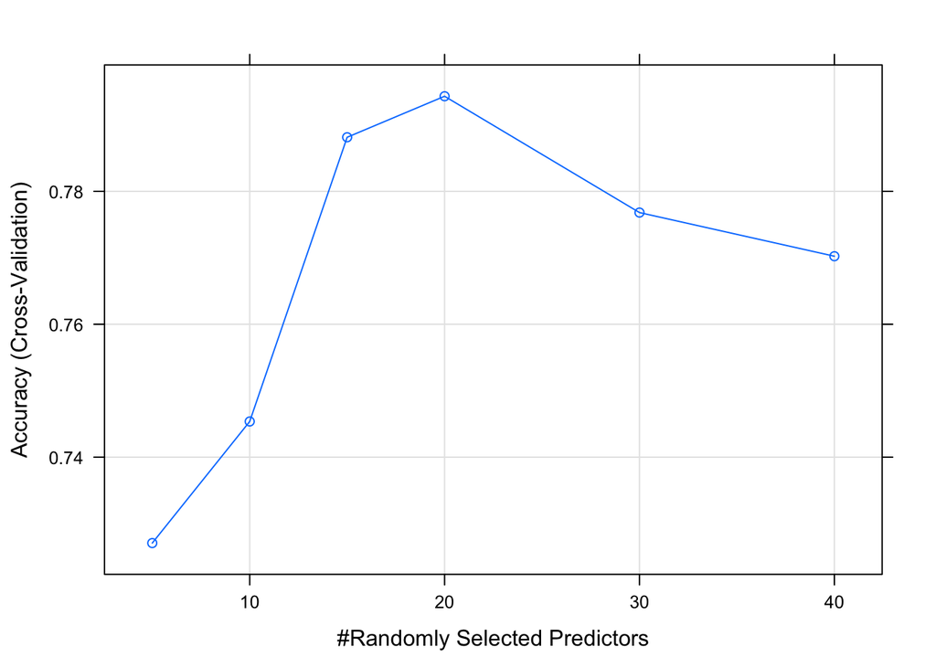

```r
plot(rfauto)
```

- Dataset 2 GBM

```r
control <- trainControl(method="cv", number=6, search="grid")

gbmGridauto <-  expand.grid(interaction.depth = c(2, 5, 10),
                        n.trees = c(500, 1000, 1500),
                        shrinkage = c(0.05,0.1, 0.2),
                        n.minobsinnode = 10)

gbmtrainauto <- train(as.factor(symboling) ~ ., data=data.table(trainauto), method="gbm", metric="Accuracy", trControl=control,tuneGrid = gbmGridauto)
```

```r
y_gbmautopredicted<-predict(gbmtrainauto,data.table(x_testauto))
table_confusiongbmauto<-table(y_testauto,y_gbmautopredicted)
gbmautotestaccuracy <- sum(diag(table_confusiongbmauto)) / sum(table_confusiongbmauto)
gbmautotrainaccuracy<-max(gbmtrainauto$results$Accuracy)

summaryauto<-rbind(summaryauto,list("gbm",gbmautotrainaccuracy,gbmautotestaccuracy))


print(as.matrix(gbmtrainauto$results))
```

```
##    shrinkage interaction.depth n.minobsinnode n.trees  Accuracy     Kappa
## 1       0.05                 2             10     500 0.7842699 0.7157646
## 10      0.10                 2             10     500 0.7659718 0.6927569
## 19      0.20                 2             10     500 0.7836237 0.7171969
## 4       0.05                 5             10     500 0.7838442 0.7148420
## 13      0.10                 5             10     500 0.7893709 0.7221453
## 22      0.20                 5             10     500 0.7897966 0.7234927
## 7       0.05                10             10     500 0.7719394 0.6973182
## 16      0.10                10             10     500 0.7959542 0.7306790
## 25      0.20                10             10     500 0.8014961 0.7405915
## 2       0.05                 2             10    1000 0.7961899 0.7308747
## 11      0.10                 2             10    1000 0.7655461 0.6913348
## 20      0.20                 2             10    1000 0.7712781 0.7017362
## 5       0.05                 5             10    1000 0.7776713 0.7072961
## 14      0.10                 5             10    1000 0.7836237 0.7145312
```

[output cut: 41 more lines]

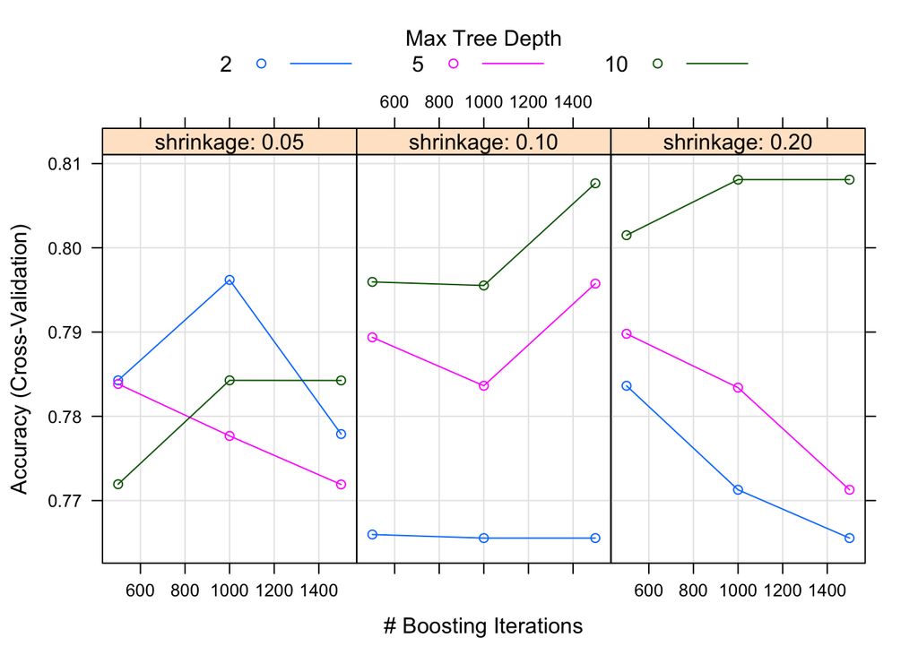

```r
plot(gbmtrainauto)
```

- Dataset 2 SVM

```r
resultsvmauto=data.table( Accuracy=numeric(), cp=numeric())
for (degree in c(2,3))
{

control <- trainControl(method="cv", number=2, search="random")
svmtrainautoinner <- train(as.matrix(x_trainrpaauto),as.factor(y_trainauto) , method="svmPoly", metric="Accuracy", tuneLength=6, trControl=control,preProcess = c("center","scale"))

svmtrainautoinner$results
resulttempsvm<-dt_news$results[,c("Accuracy","cp")]
resulttempsvm$minbucket<-degree
resultsvm<-rbind(resulttemp,results)
}
```

SVM didnt work and always endup with error (Error in x[lowerl:n, ] %*% t(y)), I searched reason of error. I think so many one-hot encoding features cause error

```r
print(as.matrix(summaryauto))
```

```
##      algorithms     AccuracyTrain AccuracyTest
## [1,] "pra"          "0.7108434"   "0.7179487"
## [2,] "dtree"        "0.6943722"   "0.6153846"
## [3,] "randomforest" "0.7943122"   "0.7435897"
## [4,] "gbm"          "0.8080946"   "0.7179487"
```

GBM gives best train accuracy but it is overfitting in test data. Random forest has best accuracy in test data.

# Dataset 3

?? used Online News Popularity Data Set (http://archive.ics.uci.edu/ml/datasets/Online+News+Popularity#). This dataset summarizes a heterogeneous set of features about articles published by Mashable in a period of two years. The goal is to predict the number of shares in social networks (popularity).It has 39000 instance and 61 features including one hot encoding categorical variable. I grouped number of shares into 2 category (popular,unpopular) to turn into classification problem

```r
#data import


library(data.table)

dt_news<-read.csv("~/Documents/Dersler/Fall-2018/IE-582/Homework4/OnlineNewsPopularity/OnlineNewsPopularity.csv",header = TRUE, sep = ",")

#sum(is.na(dt_ottotrain))

# seperate number of share in 2 category according to median (1450)
dt_news<-data.table(dt_news)
#dt_news[,`:=`(Popularity = ifelse(shares<1000,'low',ifelse(shares>3000,'high','medium')))]
dt_news[,`:=`(Popularity = ifelse(shares<1400,'unpopular','popular'))]

# remove column
dt_news<-dt_news[,-c(1,2,61)]
```

- Dataset 3 PRA

```r
# Split test and train data
training.samples <- dt_news$Popularity %>% createDataPartition(p = 0.8, list = FALSE)
trainnews<-dt_news[training.samples,]
testnews<-dt_news[-training.samples]

x_trainnews<- as.matrix(trainnews[,1:58])
y_trainnews<- ifelse(trainnews$Popularity=="unpopular",0,1)



summarynews=data.table(algorithms=character(), AccuracyTrain=numeric(),AccuracyTest=numeric())
```

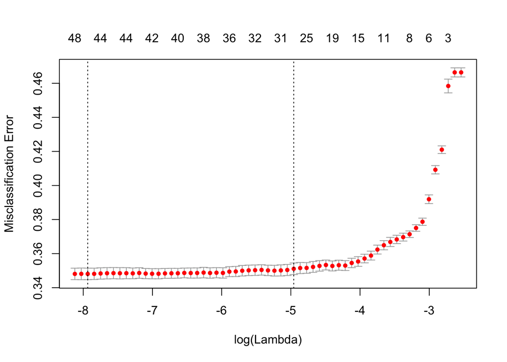

```r
#cross validation for min lambda, model find optimal lambda between random candidate
# fit the model on training data

modelrpanews <- cv.glmnet(x_trainnews, y_trainnews, alpha = 1,nfolds=10,type.measure='class',family="binomial")
rpanewstrainaccuracy<-1-min(as.numeric(modelrpanews$cvm))

x_testnews<- as.matrix(testnews[,1:58])
y_testnews<- ifelse(testnews$Popularity=="unpopular",0,1)


y_pranewspredicted<-predict(modelrpanews,x_testnews,type = "class",s=modelrpanews$lambda.min)

table_confusionrpa<-table(y_testnews,y_pranewspredicted)

pranewstestaccuracy <- sum(diag(table_confusionrpa)) / sum(table_confusionrpa)


summarynews<-rbind(summarynews,list("pra",rpanewstrainaccuracy,pranewstestaccuracy))

plot(modelrpanews)
```

```r
library(rpart)


dtresultsnews=data.table(minbucket=numeric(), Accuracy=numeric(), cp=numeric())
for (minbucket in c(5,8,10,15))
{

dtnewsGrid<-expand.grid(cp = c(0.05,0.01, 0.1, 0.15,0.20))
control <- trainControl(method="cv", number=5, search="grid")
innerdtreenews <- train(Popularity ~ ., data=trainnews, method="rpart", metric="Accuracy",minbucket =minbucket, tuneLength=5, trControl=control,tuneGrid = dtnewsGrid)

resulttemp<-innerdtreenews$results[,c("Accuracy","cp")]
resulttemp$minbucket<-minbucket
dtresultsnews<-rbind(resulttemp,dtresultsnews)
}

bestprdt<-dtresultsnews[,bestrnk:=rank(-Accuracy,ties.method= "min")][bestrnk==1]
bestminbucket<-bestprdt[,c("minbucket")]
bestcp<-bestprdt[,c("cp")]


dtnewsGrid <-  expand.grid(cp =bestcp)
control <- trainControl(method="cv", number=5, search="grid")
dtreenews <- train(Popularity ~ ., data=trainnews, method="rpart", metric="Accuracy",minbucket =bestminbucket, trControl=control,tuneGrid = dtnewsGrid)


y_dtnewspredicted<-predict(dtreenews,x_testnews)
y_dtnewspredicted<-ifelse(y_dtnewspredicted=="unpopular",0,1)
table_confusiondt<-table(y_testnews,y_dtnewspredicted)
dtreenewstestaccuracy <- sum(diag(table_confusiondt)) / sum(table_confusiondt)
dttrainnewsaccuracy<-as.numeric(bestprdt[,c("Accuracy")])


print(as.matrix(dtresultsnews))
```

```
##        Accuracy   cp minbucket bestrnk
##  [1,] 0.6292097 0.01        15       2
##  [2,] 0.5943376 0.05        15       7
##  [3,] 0.5943376 0.10        15       7
##  [4,] 0.5336108 0.15        15      15
##  [5,] 0.5336108 0.20        15      15
##  [6,] 0.6270338 0.01        10       4
##  [7,] 0.5940217 0.05        10       9
##  [8,] 0.5940217 0.10        10       9
##  [9,] 0.5336108 0.15        10      13
## [10,] 0.5336108 0.20        10      13
## [11,] 0.6270967 0.01         8       3
## [12,] 0.5930129 0.05         8      11
## [13,] 0.5930129 0.10         8      11
## [14,] 0.5336108 0.15         8      15
## [15,] 0.5336108 0.20         8      15
## [16,] 0.6332452 0.01         5       1
## [17,] 0.5945266 0.05         5       5
## [18,] 0.5945266 0.10         5       5
## [19,] 0.5336108 0.15         5      15
## [20,] 0.5336108 0.20         5      15
```

```r
summarynews<-rbind(summarynews,list("dtree",dttrainnewsaccuracy,dtreenewstestaccuracy))
```

```r
# Grid Tuning
control <- trainControl(method="cv", number=2, search="grid")

# nodesize(the minimal number of observations per tree leaf) is 5, number of tree 500,
#tunelength gives 6 random mtry value for tuning

rfnewsgrid<-expand.grid(mtry = c(5,10, 15,30))
rfnews <- train(Popularity ~ ., data=trainnews, method="rf", metric="Accuracy",ntree =500,nodesize=5, trControl=control,tuneGrid = rfnewsgrid)

y_rfnewspredicted<-predict(rfnews,x_testnews)
y_rfnewspredicted<-ifelse(y_rfnewspredicted=="unpopular",0,1)
table_confusiondt<-table(y_testnews,y_rfnewspredicted)
rfnewstestaccuracy <- as.numeric(sum(diag(table_confusiondt)) / sum(table_confusiondt))
rfnewstrainaccuracy<-as.numeric(max(rfnews$results$Accuracy))

summarynews<-rbind(summarynews,list("randomforest",rfnewstrainaccuracy,rfnewstestaccuracy))

print(rfnews)
```

```
## Random Forest
##
## 31716 samples
##    58 predictor
##     2 classes: 'popular', 'unpopular'
##
## No pre-processing
## Resampling: Cross-Validated (2 fold)
## Summary of sample sizes: 15858, 15858
## Resampling results across tuning parameters:
##
##   mtry  Accuracy   Kappa
##    5    0.6674864  0.3258275
##   10    0.6657523  0.3231455
##   15    0.6637344  0.3193280
##   30    0.6638605  0.3202866
##
## Accuracy was used to select the optimal model using the largest value.
## The final value used for the model was mtry = 5.
```

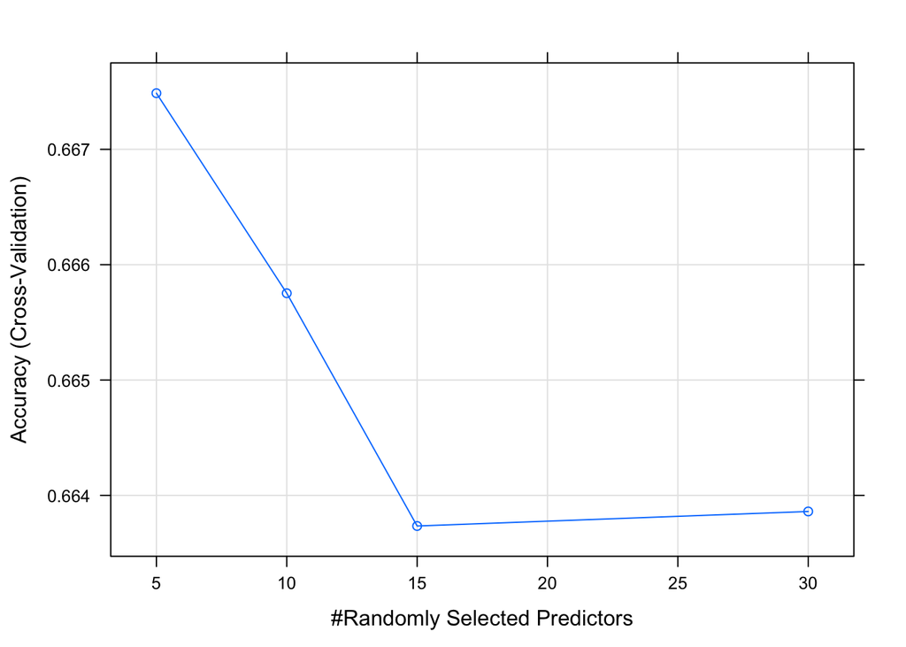

```r
plot(rfnews)
```

```r
control <- trainControl(method="cv", number=2, search="grid")

gbmGrid <-  expand.grid(interaction.depth = c(2, 5, 9),
                        n.trees = c(500, 1000, 1500),
                        shrinkage = c(0.05,0.1, 0.2),
                        n.minobsinnode = 10)

gbmtrainnews <- train(Popularity ~ ., data=trainnews, method="gbm", metric="Accuracy", trControl=control,tuneGrid = gbmGrid)
```

```r
y_gbmnewspredicted<-predict(gbmtrainnews,x_testnews)
y_gbmnewspredicted<-ifelse(y_gbmnewspredicted=="unpopular",0,1)
table_confusiongbm<-table(y_testnews,y_gbmnewspredicted)
gbmnewstestaccuracy <- sum(diag(table_confusiongbm)) / sum(table_confusiongbm)
gbmnewstrainaccuracy<-max(gbmtrainnews$results$Accuracy)

summarynews<-rbind(summarynews,list("GBM",gbmnewstrainaccuracy,gbmnewstestaccuracy))


print(as.matrix(gbmtrainnews$results))
```

```
##    shrinkage interaction.depth n.minobsinnode n.trees  Accuracy     Kappa
## 1       0.05                 2             10     500 0.6674864 0.3287202
## 10      0.10                 2             10     500 0.6683062 0.3309748
## 19      0.20                 2             10     500 0.6620948 0.3195887
## 4       0.05                 5             10     500 0.6696620 0.3335352
## 13      0.10                 5             10     500 0.6630092 0.3209810
## 22      0.20                 5             10     500 0.6507126 0.2966958
## 7       0.05                 9             10     500 0.6700088 0.3344199
## 16      0.10                 9             10     500 0.6604868 0.3160162
## 25      0.20                 9             10     500 0.6446588 0.2847471
## 2       0.05                 2             10    1000 0.6670766 0.3285285
## 11      0.10                 2             10    1000 0.6683693 0.3314687
## 20      0.20                 2             10    1000 0.6597301 0.3149826
## 5       0.05                 5             10    1000 0.6683377 0.3310685
## 14      0.10                 5             10    1000 0.6612435 0.3175234
```

[output cut: 41 more lines]

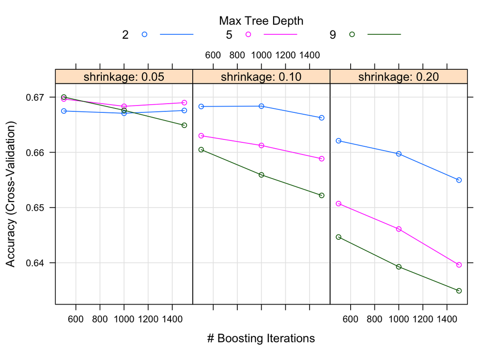

```r
plot(gbmtrainnews)
```

```r
#Because of long run time, ?? took sample

trainsvm <- trainnews$Popularity %>% createDataPartition(p = 0.6, list = FALSE)
trainsvm<-trainnews[trainsvm,]
x_trainnews<- as.matrix(trainsvm[,1:58])
y_trainnews<- ifelse(trainsvm$Popularity=="unpopular",0,1)


resultsvm=data.table(minbucket=numeric(), Accuracy=numeric(), cp=numeric())
for (degree in c(2,3,4))
{

control <- trainControl(method="cv", number=2, search="random")
svmtrainnewsinner <- train(Popularity ~ ., data=trainnews, method="svmPoly", metric="Accuracy",degree=2, tuneLength=3, trControl=control)
resulttempsvm<-dt_news$results[,c("Accuracy","cp")]
resulttempsvm$minbucket<-degree
resultsvm<-rbind(resulttemp,results)
}
```

SVM take so much time (over 2 hour), so ?? only write code(it was accepted in class)

```r
print(summarynews)
```

```
##      algorithms AccuracyTrain AccuracyTest
## 1:          pra     0.6519107    0.6547679
## 2:        dtree     0.6332452    0.6256307
## 3: randomforest     0.6674864    0.6709132
## 4:          GBM     0.6700088    0.6822654
```

## Dataset 4 (Regression)

```r
datacrime=read.table("~/Documents/Dersler/Fall-2018/IE-582/Homework4/communities.data.txt",header = FALSE, sep = ",")
dt_crime<-data.table(datacrime)
dt_crime[dt_crime=='?']<-NA


#if %80 of value is missing, exclude features
dt_crime<-dt_crime[,-c(1:6,102:118,122:125,127)]
dt_crime<-na.omit(dt_crime)

training.crime <- dt_crime$V128 %>% createDataPartition(p = 0.8, list = FALSE)
traincrime<-dt_crime[training.crime,]
testcrime<-dt_crime[-training.crime]

x_traincrime<- as.matrix(traincrime[,1:99])
y_traincrime<- traincrime$V128


x_testcrime<- as.matrix(testcrime[,1:99])
y_testcrime<- testcrime$V128

summarycrime=data.table(algorithms=character(), RMSETrain=numeric(),RMSETest=numeric())
```

# Dataset 4 PRA

- Model

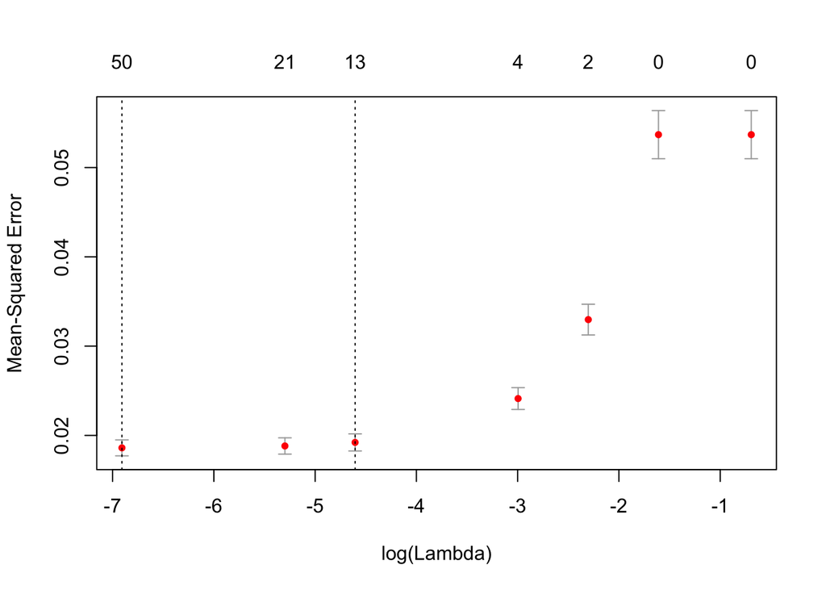

```r
modelpracrime <- cv.glmnet(as(x_traincrime,"dgCMatrix"), y_traincrime, alpha = 1,nfolds=10,type.measure='mse',lambda = c(0.005,0.001,0.01,0.05,0.1,0.2,0.5))

# model found best lambda for min mse but ?? transform train metric into rmse to evaluate other methods(best mse probably is equal to the best rmse)
y_pracrimepretrain<-predict(modelpracrime,as(x_traincrime,"dgCMatrix"),s=modelpracrime$lambda.min)
y_pracrimepredicted<-predict(modelpracrime,as(x_testcrime,"dgCMatrix"),s=modelpracrime$lambda.min)



pracrimetrainmse<-rmse(y_traincrime,y_pracrimepretrain) ## trainmse  0.19
pracrimetestmse<-rmse(y_testcrime,y_pracrimepredicted) ## test mse 0.15

plot(modelpracrime)
```

```r
summarycrime<-rbind(summarycrime,list("pra",pracrimetrainmse,pracrimetestmse))
```

- Dataset 4 Decision Tree
- Model

```r
dtresultscrime=data.table(minbucket=numeric(), RMSE=numeric(), cp=numeric())

#find best parameter
for (minbucket in c(5,8,10,15,20))
{

dtcrimeGrid<-expand.grid(cp = c(0.005,0.05,0.01, 0.1, 0.15))
control <- trainControl(method="cv", number=6, search="grid")
innerdtreecrime <- train(V128 ~ ., data=traincrime, method="rpart", metric="RMSE",minbucket =minbucket, tuneLength=5, trControl=control,tuneGrid = dtcrimeGrid)

resulttempcrime<-innerdtreecrime$results[,c("RMSE","cp")]
resulttempcrime$minbucket<-minbucket
dtresultscrime<-rbind(resulttempcrime,dtresultscrime)
}

bestprdtcrime<-dtresultscrime[,bestrnk:=rank(RMSE,ties.method= "min")][bestrnk==1]
bestminbucketcrime<-bestprdtcrime[,c("minbucket")]
bestcpcrime<-bestprdtcrime[,c("cp")]


print(as.matrix(dtresultscrime))
```

```
##            RMSE    cp minbucket bestrnk
##  [1,] 0.1501440 0.005        20       1
##  [2,] 0.1501805 0.010        20       2
##  [3,] 0.1639255 0.050        20      11
##  [4,] 0.1768282 0.100        20      16
##  [5,] 0.1768282 0.150        20      16
##  [6,] 0.1607738 0.005        15      10
##  [7,] 0.1543442 0.010        15       6
##  [8,] 0.1669528 0.050        15      15
##  [9,] 0.1786908 0.100        15      24
## [10,] 0.1786908 0.150        15      24
## [11,] 0.1541651 0.005        10       5
## [12,] 0.1518558 0.010        10       3
## [13,] 0.1666561 0.050        10      14
## [14,] 0.1784879 0.100        10      22
## [15,] 0.1784879 0.150        10      22
## [16,] 0.1575477 0.005         8       7
## [17,] 0.1581726 0.010         8       8
## [18,] 0.1652771 0.050         8      13
## [19,] 0.1776764 0.100         8      20
## [20,] 0.1776764 0.150         8      20
## [21,] 0.1588167 0.005         5       9
## [22,] 0.1540715 0.010         5       4
## [23,] 0.1647028 0.050         5      12
## [24,] 0.1773425 0.100         5      18
## [25,] 0.1773425 0.150         5      18
```

- Evaluation

```r
#fit model best parameter

dtcrimeGrid <-  expand.grid(cp =bestcpcrime)
control <- trainControl(method="cv", number=3, search="grid")
dtreecrime <- train(V128 ~ ., data=traincrime, method="rpart", metric="RMSE",minbucket =bestminbucketcrime, trControl=control,tuneGrid = dtcrimeGrid)
#dtreecrime <- train(x_traincrime,y_traincrime, method="rpart", minbucket =bestminbucketcrime, trControl=control,tuneGrid = dtcrimeGrid)



y_dtcrimepredicted<-predict(dtreecrime,testcrime[,1:99])
#y_dtcrimepredicted<-ifelse(y_dtnewspredicted=="unpopular",0,1)
dtreecrimetestaccuracy <- rmse(y_testcrime,y_dtcrimepredicted)
dtreecrimetrainaccuracy<-as.numeric(bestprdtcrime[1,c("RMSE")])


summarycrime<-rbind(summarycrime,list("dtree",dtreecrimetrainaccuracy,dtreecrimetestaccuracy))

print(as.matrix(dtresultscrime))
```

```
##            RMSE    cp minbucket bestrnk
##  [1,] 0.1501440 0.005        20       1
##  [2,] 0.1501805 0.010        20       2
##  [3,] 0.1639255 0.050        20      11
##  [4,] 0.1768282 0.100        20      16
##  [5,] 0.1768282 0.150        20      16
##  [6,] 0.1607738 0.005        15      10
##  [7,] 0.1543442 0.010        15       6
##  [8,] 0.1669528 0.050        15      15
##  [9,] 0.1786908 0.100        15      24
## [10,] 0.1786908 0.150        15      24
## [11,] 0.1541651 0.005        10       5
## [12,] 0.1518558 0.010        10       3
## [13,] 0.1666561 0.050        10      14
## [14,] 0.1784879 0.100        10      22
## [15,] 0.1784879 0.150        10      22
## [16,] 0.1575477 0.005         8       7
## [17,] 0.1581726 0.010         8       8
## [18,] 0.1652771 0.050         8      13
## [19,] 0.1776764 0.100         8      20
## [20,] 0.1776764 0.150         8      20
## [21,] 0.1588167 0.005         5       9
## [22,] 0.1540715 0.010         5       4
## [23,] 0.1647028 0.050         5      12
## [24,] 0.1773425 0.100         5      18
## [25,] 0.1773425 0.150         5      18
```

- Dataset 4 Random Forest

```r
# Grid search
control <- trainControl(method="cv", number=6, search="grid")

# nodesize(the minimal number of observations per tree leaf) is 5, number of tree 500,
# 6  mtry value for tuning

rfcrimegrid<-expand.grid(mtry = c(5,10, 20,30,40))
rfcrime <- train(V128 ~ ., data=traincrime, method="rf", metric="RMSE",ntree =500,nodesize=5, trControl=control,tuneGrid = rfcrimegrid)

y_rfcrimepredicted<-predict(rfcrime,testcrime[,1:99])
rfcrimetestaccuracy <- rmse(y_testcrime,y_dtcrimepredicted)
rfcrimetrainaccuracy<-as.numeric(min(rfcrime$results$RMSE))

summarycrime<-rbind(summarycrime,list("randomforest",rfcrimetrainaccuracy,rfcrimetestaccuracy))

print(rfcrime)
```

```
## Random Forest
##
## 1596 samples
##   99 predictor
##
## No pre-processing
## Resampling: Cross-Validated (6 fold)
## Summary of sample sizes: 1331, 1331, 1329, 1330, 1329, 1330, ...
## Resampling results across tuning parameters:
##
##   mtry  RMSE       Rsquared   MAE
##    5    0.1367765  0.6647388  0.09515060
##   10    0.1344153  0.6702793  0.09317392
##   20    0.1335302  0.6716204  0.09216666
##   30    0.1338179  0.6690453  0.09199475
##   40    0.1336218  0.6699165  0.09187553
##
## RMSE was used to select the optimal model using the smallest value.
## The final value used for the model was mtry = 20.
```

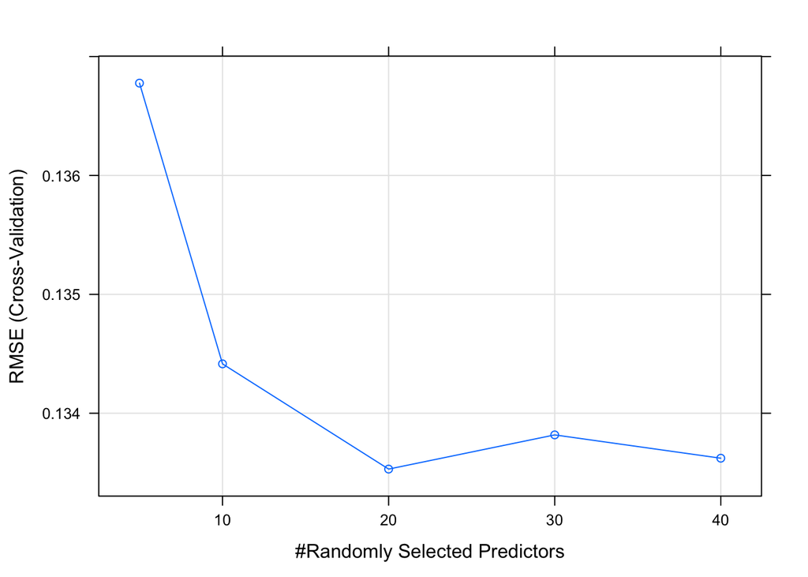

```r
plot(rfcrime)
```

- Dataset 4 GBM

```r
control <- trainControl(method="cv", number=3, search="grid")

gbmGridcrime <-  expand.grid(interaction.depth = c(2, 5, 10),
                        n.trees = c(500, 1000, 1500),
                        shrinkage = c(0.05,0.1, 0.2),
                        n.minobsinnode = 10)

gbmtraincrime <- train(V128 ~ ., data=traincrime, method="gbm", metric="RMSE", trControl=control,tuneGrid = gbmGridcrime)



#gbmtrainbank$bestTune
```

```r
y_gbmcrimepredicted<-predict(gbmtraincrime,testcrime[,1:99])
gbmcrimetestrmse <- rmse(y_testcrime,y_gbmcrimepredicted)
gbmcrimetrainrmse<-min(gbmtraincrime$results$RMSE)


summarycrime<-rbind(summarycrime,list("gbm",gbmcrimetrainrmse,gbmcrimetestrmse))

print(as.matrix(gbmtraincrime$results))
```

```
##    shrinkage interaction.depth n.minobsinnode n.trees      RMSE  Rsquared
## 1       0.05                 2             10     500 0.1362589 0.6551526
## 10      0.10                 2             10     500 0.1396782 0.6398940
## 19      0.20                 2             10     500 0.1429615 0.6264427
## 4       0.05                 5             10     500 0.1353961 0.6591147
## 13      0.10                 5             10     500 0.1398907 0.6399538
## 22      0.20                 5             10     500 0.1495811 0.5978671
## 7       0.05                10             10     500 0.1359151 0.6580015
## 16      0.10                10             10     500 0.1393747 0.6437577
## 25      0.20                10             10     500 0.1477043 0.6090728
## 2       0.05                 2             10    1000 0.1370737 0.6513318
## 11      0.10                 2             10    1000 0.1417107 0.6315099
## 20      0.20                 2             10    1000 0.1463153 0.6121177
## 5       0.05                 5             10    1000 0.1369797 0.6518990
## 14      0.10                 5             10    1000 0.1412822 0.6338459
```

[output cut: 41 more lines]

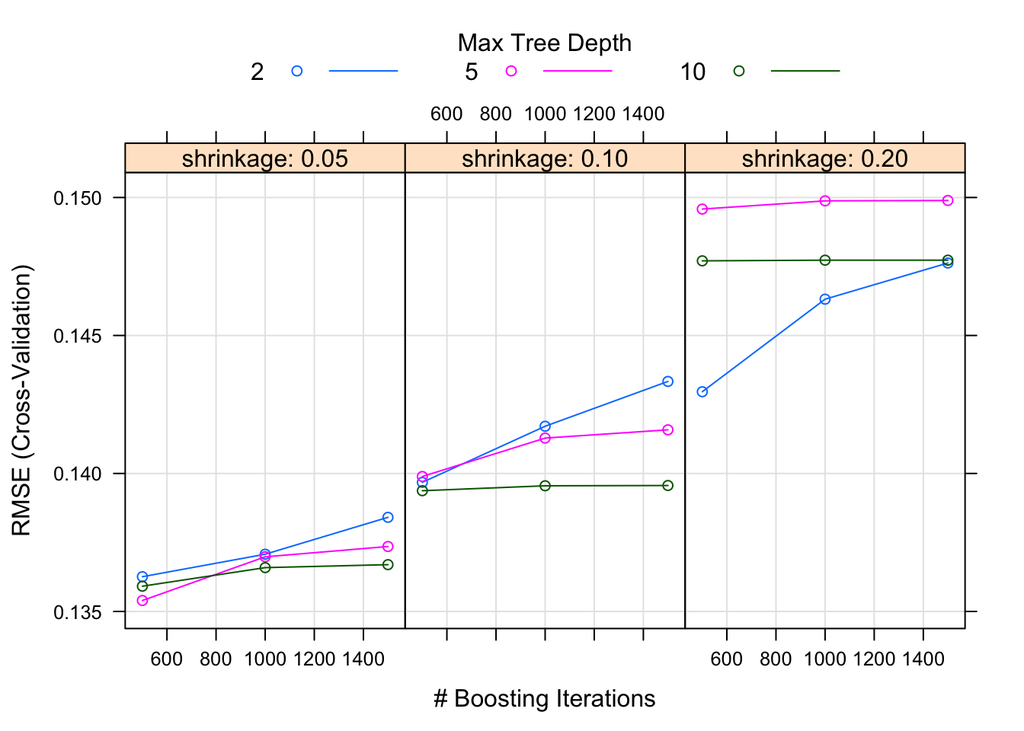

```r
plot(gbmtraincrime)
```

- Dataset 4 SVM

```r
resultsvmcrime=data.table(minbucket=numeric(), Accuracy=numeric(), cp=numeric())
for (degree in c(1,2,3))
{
SVMgrid <- expand.grid(sigma = c(0.0577), C = c(2.21049))
control <- trainControl(method="cv", number=2, search="random")
svmtraincrimeinner <- train(V128 ~ ., data=as.matrix(traincrime), method="svmPoly",degree=degree, tuneLength=3, trControl=control,preProcess = c("center","scale"))

#svmtraincrimeinner <- train(V128 ~ ., data=as.matrix(traincrime), method="svmRadial",tuneGrid = SVMgrid,preProcess = c("center","scale"))

svmtraincrimeinner$results
resulttempsvm<-dt_news$results[,c("Accuracy","cp")]
resulttempsvm$minbucket<-degree
resultsvm<-rbind(resulttemp,results)

}
```

SVM take so much time (over 2 hour), so ?? only write code(it was accepted in class)

- Dataset 4 Summary

```r
print(summarycrime)
```

```
##      algorithms RMSETrain  RMSETest
## 1:          pra 0.1313290 0.1351439
## 2:        dtree 0.1501440 0.1650155
## 3: randomforest 0.1335302 0.1650155
## 4:          gbm 0.1353961 0.1432435
```

PRA models give best train and test RMSE, GBM model is overfitting in train data.

- General Summary

GBM and Random forest models generally gives better result than others except regression, but GBM models may overfit. Tuning parameter has high importance in accuracy, it can effect accuracy dramatically even in small change.